```r
library(tidyverse)
library(caret)
library(readxl)
library(stargazer)
library(e1071)
library(partykit)

set.seed(6527)
```

# Data

First, we read all non-standard uses which did not require preprocessing.

```r
he_ns <- read_excel("he_ns.xlsx")
she_ns <- read_excel("she_ns_1.xlsx")
she_ns <- rbind(she_ns, read_excel("she_ns_2.xlsx"))
they_ns <- read_excel("they_ns.xlsx")
```

Here, we label them as `ns` (non-standard).

```r
he_ns %>%
  mutate(pron="he", type="ns") -> he_ns

she_ns %>%
  mutate(pron="she", type="ns") -> she_ns


they_ns %>%
  mutate(pron="they", type="ns") -> they_ns
```

Second, the preprocessed data on standard uses was loaded.

```r
he_s <- read_excel("standard_forms.xlsx", sheet = "he")
she_s <- read_excel("standard_forms.xlsx", sheet = "she")
they_s <- read_excel("standard_forms.xlsx", sheet = "they")
```

And labeled.

```r
he_s %>%
  mutate(pron="he", type="s") -> he_s

she_s %>%
  mutate(pron="she", type="s") -> she_s

they_s %>%
  mutate(pron="they", type="s") -> they_s
```

Now, we combined them all together into one dataset.

```r
df <- rbind(he_ns, she_ns, they_ns, he_s, she_s, they_s)
```

The preprocessed file with metadata on speaker was loaded here. We also merge our dataset with it and select only needed columns.

```r
meta <- read_excel("metadata_unified.xlsx")
merge(df, meta, by.x = "person_id", by.y = "id") %>%
  select(person_id, pron, type, gender, birthyear, birthplace,
         relative_to_mikh, education_school, education_add, job_norm,
         livingplace) -> final_data
```

Here, the data are preprocessed.

```r
final_data %>%
  mutate(education_school = replace_na(as.numeric(education_school), 0),
         education_add = factor(education_add,
                                levels = c("-", "courses", "college", "university"))
         ) -> final_data

final_data[is.na(final_data)] <- "-"

final_data$pron <- as.factor(final_data$pron)
final_data$gender <- as.factor(final_data$gender)
final_data$relative_to_mikh <- as.factor(final_data$relative_to_mikh)
final_data$job_norm <- as.factor(final_data$job_norm)
final_data$livingplace <- as.factor(final_data$livingplace)
```

The summary is as follows.

```r
summary(final_data)
```

```
##   person_id           pron         type           gender    birthyear
##  Length:229         he  :114   Length:229         ж:196   Min.   :1922
##  Class :character   she : 40   Class :character   м: 33   1st Qu.:1930
##  Mode  :character   they: 75   Mode  :character           Median :1947
##                                                           Mean   :1945
##                                                           3rd Qu.:1954
##                                                           Max.   :1975
##
##   birthplace              relative_to_mikh education_school    education_add
##  Length:229         -             :127     Min.   : 0.000   -         :125
##  Class :character   north         : 52     1st Qu.: 4.000   courses   : 23
##  Mode  :character   far_south_east: 15     Median : 8.000   college   : 75
##                     south         : 14     Mean   : 5.463   university:  6
##                     east          : 13     3rd Qu.: 8.000
##                     far_east      :  5     Max.   :12.000
##                     (Other)       :  3
##        job_norm           livingplace
##  accountant:49   -              :  7
##  -         :45   Акичкин Починок: 18
##  milkmaid  :37   Бестужево      :  5
##  seller    :32   Домодедово     :  2
##  kolhoz    :30   Михалевская    :194
##  farmer    :12   Плосское       :  3
##  (Other)   :24
```

Some visualization.

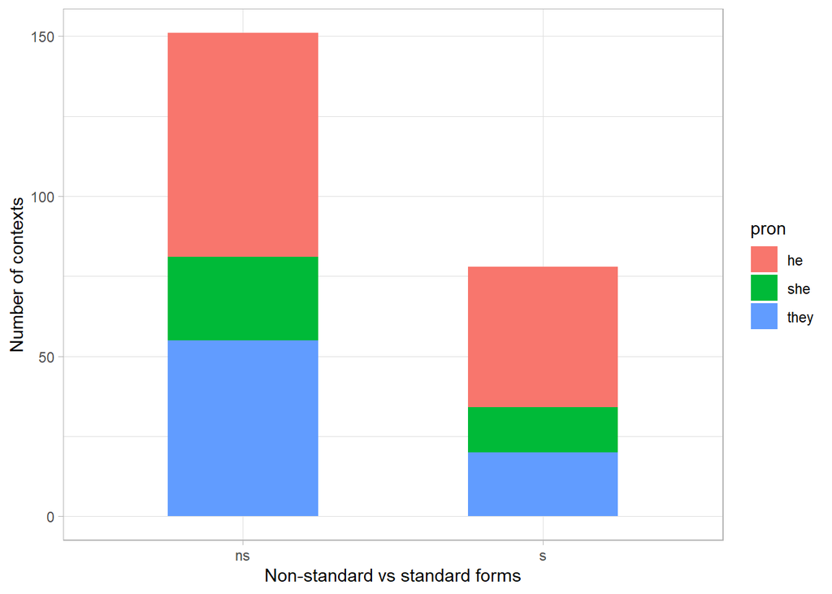

```r
ggplot(final_data, aes(type, fill=pron))+
  geom_bar(width = 0.5)+
  theme_light()+
  theme(legend.position="right")+
  ylab("Number of contexts")+
  xlab("Non-standard vs standard forms")
```

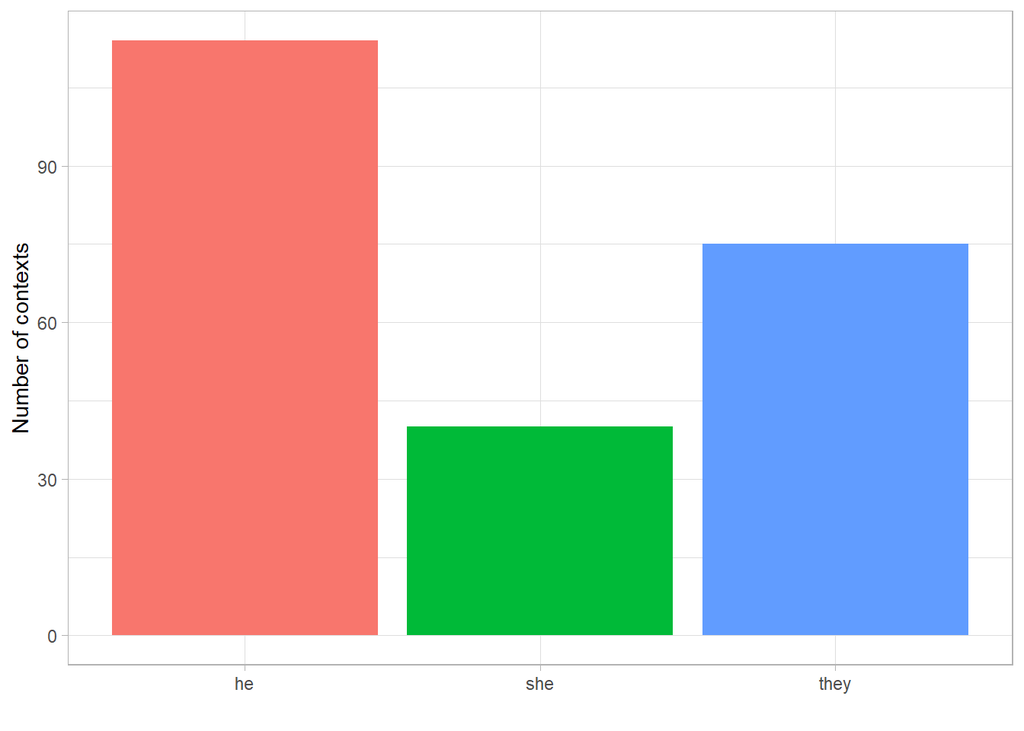

```r
ggplot(final_data, aes(pron, fill=pron))+
  geom_bar()+
  theme_light()+
  theme(legend.position="none")+
  ylab("Number of contexts")+
  xlab("")
```

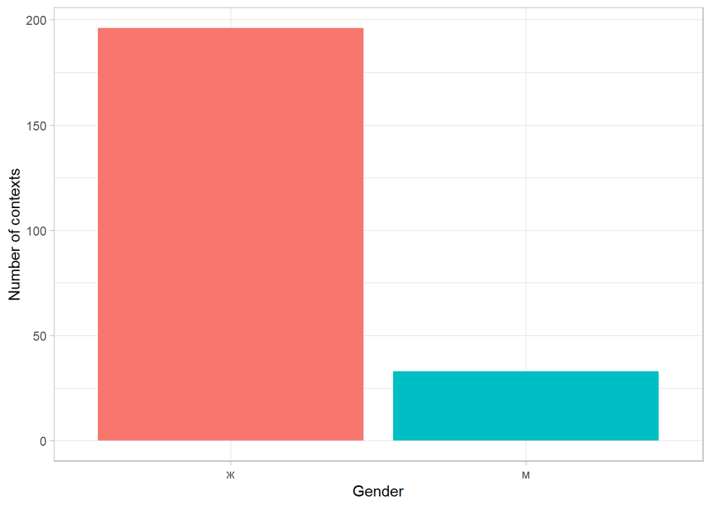

```r
ggplot(final_data, aes(gender, fill=gender))+
  geom_bar()+
  theme_light()+
  ylab("Number of contexts")+
  theme(legend.position="none")+
  xlab("Gender")
```

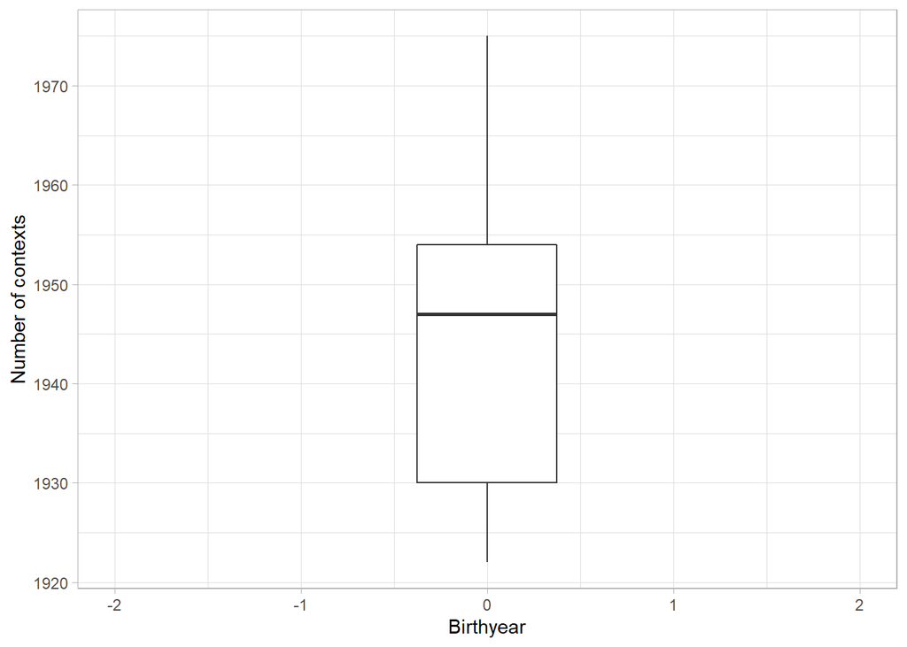

```r
ggplot(final_data, aes(y=birthyear, x=0))+
  geom_boxplot()+
  xlim(c(-2, 2))+
  theme_light()+
  ylab("Number of contexts")+
  xlab("Birthyear")
```

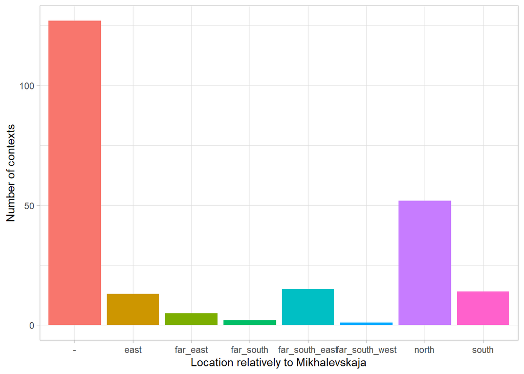

```r
ggplot(final_data, aes(relative_to_mikh, fill=relative_to_mikh))+
  geom_bar()+
  theme_light()+
  theme(legend.position="none")+
  ylab("Number of contexts")+
  xlab("Location relatively to Mikhalevskaja")
```

# Analysis

```r
final_data %>%
  mutate(type = ifelse(type == "ns", 0, 1)) -> final_data

model <- glm(type ~ pron+gender+birthyear+education_school+education_add+relative_to_mikh,
            data=final_data)
stargazer(model,
          type="text",
          p.auto = TRUE,
          single.row=TRUE,
          ci=TRUE, ci.level=0.95,
          report='vscp*')
```

```
##
## ==========================================================
##                                    Dependent variable:
##                                ---------------------------
##                                           type
## ----------------------------------------------------------
## pronshe                          -0.007 (-0.175, 0.160)
##                                         p = 0.931
## pronthey                         -0.083 (-0.217, 0.050)
##                                         p = 0.223
## genderм                          -0.232 (-0.443, -0.021)
##                                        p = 0.033**
## birthyear                         0.009 (0.003, 0.015)
##                                       p = 0.004***
## education_school                 -0.016 (-0.041, 0.008)
##                                         p = 0.191
## education_addcourses             -0.013 (-0.263, 0.237)
##                                         p = 0.918
## education_addcollege              0.004 (-0.186, 0.195)
##                                         p = 0.964
## education_adduniversity           0.422 (-0.167, 1.011)
##                                         p = 0.162
## relative_to_mikheast              0.133 (-0.219, 0.485)
##                                         p = 0.461
## relative_to_mikhfar_east          0.279 (-0.124, 0.682)
##                                         p = 0.177
## relative_to_mikhfar_south        -0.515 (-1.143, 0.113)
##                                         p = 0.110
## relative_to_mikhfar_south_east    0.561 (0.313, 0.810)
##                                      p = 0.00002***
## relative_to_mikhfar_south_west    0.762 (-0.102, 1.626)
##                                        p = 0.086*
## relative_to_mikhnorth             0.060 (-0.089, 0.208)
##                                         p = 0.433
## relative_to_mikhsouth             0.300 (0.046, 0.555)
##                                        p = 0.022**
## Constant                        -17.575 (-29.472, -5.677)
##                                       p = 0.005***
## ----------------------------------------------------------
## Observations                               229
## Log Likelihood                          -125.235
## Akaike Inf. Crit.                        282.470
## ==========================================================
## Note:                          *p<0.1; **p<0.05; ***p<0.01
```

We check whether the model is adequate and is not disbalanced.

```r
pred <- predict(model)
pred <- ifelse(pred < 0.3, 0, 1)
confusionMatrix(data=as.factor(pred),
                reference = as.factor(final_data$type))
```

```
## Confusion Matrix and Statistics
##
##           Reference
## Prediction   0   1
##          0 110  22
##          1  41  56
##
##                Accuracy : 0.7249
##                  95% CI : (0.6622, 0.7817)
##     No Information Rate : 0.6594
##     P-Value [Acc > NIR] : 0.02026
##
##                   Kappa : 0.4216
##
##  Mcnemar's Test P-Value : 0.02334
##
##             Sensitivity : 0.7285
##             Specificity : 0.7179
##          Pos Pred Value : 0.8333
##          Neg Pred Value : 0.5773
##              Prevalence : 0.6594
##          Detection Rate : 0.4803
##    Detection Prevalence : 0.5764
##       Balanced Accuracy : 0.7232
##
##        'Positive' Class : 0
##
```

Now, we run a series of chi-square tests to check whether `type` is independent from other factors, namely `gender`, `birthyear`, `education_school`, `education_add`, and `relative_to_mikh`.

```r
final_data %>%
  select(gender, type) %>%
  table %>%
  chisq.test(simulate.p.value=TRUE)
```

```
##
##  Pearson's Chi-squared test with simulated p-value (based on 2000
##  replicates)
##
## data:  .
## X-squared = 2.8342, df = NA, p-value = 0.1159
```

```r
final_data %>%
  select(birthyear, type) %>%
  table %>%
  chisq.test(simulate.p.value=TRUE)
```

```
##
##  Pearson's Chi-squared test with simulated p-value (based on 2000
##  replicates)
##
## data:  .
## X-squared = 48.042, df = NA, p-value = 0.0009995
```

```r
final_data %>%
  select(education_school, type) %>%
  table %>%
  chisq.test(simulate.p.value=TRUE)
```

```
##
##  Pearson's Chi-squared test with simulated p-value (based on 2000
##  replicates)
##
## data:  .
## X-squared = 20.886, df = NA, p-value = 0.007496
```

```r
final_data %>%
  select(education_add, type) %>%
  table %>%
  chisq.test(simulate.p.value=TRUE)
```

```
##
##  Pearson's Chi-squared test with simulated p-value (based on 2000
##  replicates)
##
## data:  .
## X-squared = 13.999, df = NA, p-value = 0.002999
```

```r
final_data %>%
  select(relative_to_mikh, type) %>%
  table %>%
  chisq.test(simulate.p.value=TRUE)
```

```
##
##  Pearson's Chi-squared test with simulated p-value (based on 2000
##  replicates)
##
## data:  .
## X-squared = 33.002, df = NA, p-value = 0.0004998
```

And the final model is a decision tree.

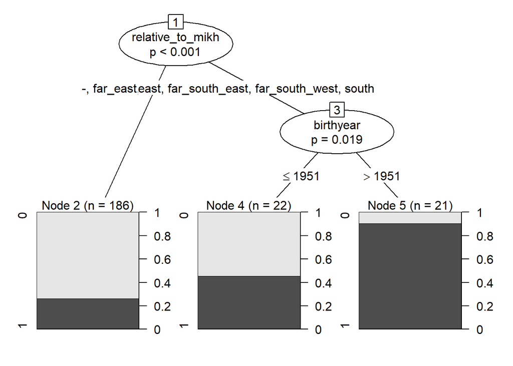

```r
final_data$birthplace <- NULL
final_data$person_id <- NULL

final_data$type <- as.factor(final_data$type)

tree_type <- ctree(type ~ ., data=final_data)
plot(tree_type)
```